# COMPSCIX 415.3 Homework 4

Inessa Wu

February 20, 2018

```r
library(tidyverse)
library(nycflights13)
```

### Exercise 5.6.7

2.Come up with another approach that will give you the same output as not_cancelled %>% count(dest)

```r
not_cancelled <- flights %>%
  filter(!is.na(dep_delay), !is.na(arr_delay))
not_cancelled %>%
  count(dest)
```

```
## # A tibble: 104 x 2
##    dest      n
##    <chr> <int>
##  1 ABQ     254
##  2 ACK     264
##  3 ALB     418
##  4 ANC       8
##  5 ATL   16837
##  6 AUS    2411
##  7 AVL     261
##  8 BDL     412
##  9 BGR     358
## 10 BHM     269
## # ... with 94 more rows
```

```r
not_cancelled <- flights %>%
  filter(!is.na(dep_delay), !is.na(arr_delay))

not_cancelled %>% group_by(dest) %>%
  summarize (n=n())
```

```
## # A tibble: 104 x 2
##    dest      n
##    <chr> <int>
##  1 ABQ     254
##  2 ACK     264
##  3 ALB     418
##  4 ANC       8
##  5 ATL   16837
##  6 AUS    2411
##  7 AVL     261
##  8 BDL     412
##  9 BGR     358
## 10 BHM     269
## # ... with 94 more rows
```

Come up with another approach that will give you the same output as not_cancelled %>% count(tailnum, wt = distance) (without using count()).

```r
not_cancelled <- flights %>%
  filter(!is.na(dep_delay), !is.na(arr_delay))

not_cancelled %>% count(tailnum, wt = distance)
```

```
## # A tibble: 4,037 x 2
##    tailnum      n
##    <chr>    <dbl>
##  1 D942DN    3418
##  2 N0EGMQ  239143
##  3 N10156  109664
##  4 N102UW   25722
##  5 N103US   24619
##  6 N104UW   24616
##  7 N10575  139903
##  8 N105UW   23618
##  9 N107US   21677
## 10 N108UW   32070
## # ... with 4,027 more rows
```

```r
not_cancelled <- flights %>%
  filter(!is.na(dep_delay), !is.na(arr_delay))

not_cancelled %>% group_by (tailnum) %>%
  summarize(n = sum(distance))
```

```
## # A tibble: 4,037 x 2
##    tailnum      n
##    <chr>    <dbl>
##  1 D942DN    3418
##  2 N0EGMQ  239143
##  3 N10156  109664
##  4 N102UW   25722
##  5 N103US   24619
##  6 N104UW   24616
##  7 N10575  139903
##  8 N105UW   23618
##  9 N107US   21677
## 10 N108UW   32070
## # ... with 4,027 more rows
```

4. Look at the number of cancelled flights per day. Is there a pattern? Is the proportion of cancelled flights related to the average delay?

I don’t see any pattern between the departure date and the number of cancelled flights. There is linear relationship between the number of cancelled flights and the proportion of cancelled flights. Number of cancelled flights increases with the increase in average departure delay.

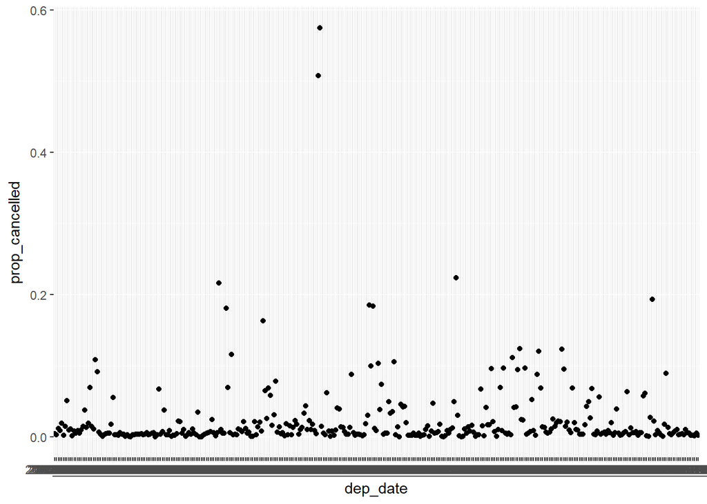

```r
flights_pattern <- flights %>%
  unite(dep_date, year, month, day) %>%
  group_by(dep_date) %>%
  summarize (cancelled_flights = sum(is.na(dep_delay)),
             prop_cancelled = mean(is.na(dep_delay)),
             mean_delay = mean (arr_delay, na.rm = TRUE))

ggplot(data = flights_pattern) +
         geom_point(mapping = aes(x=dep_date, y=prop_cancelled))
```

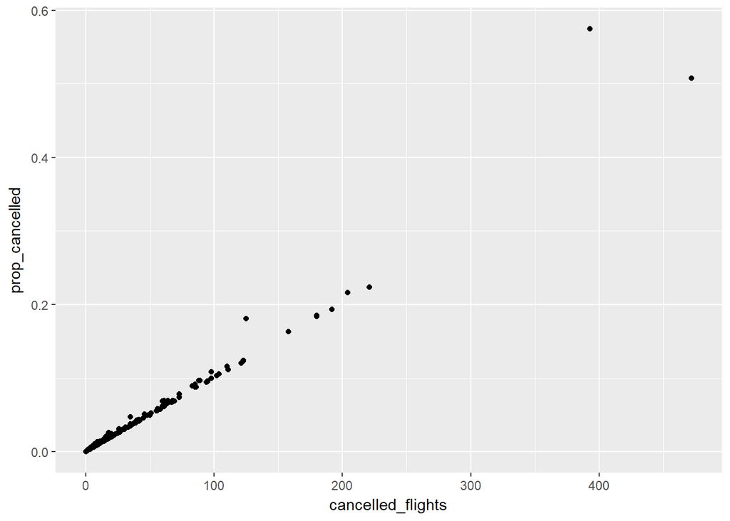

```r
ggplot(data = flights_pattern) +
         geom_point(mapping = aes(x=cancelled_flights, y=prop_cancelled))
```

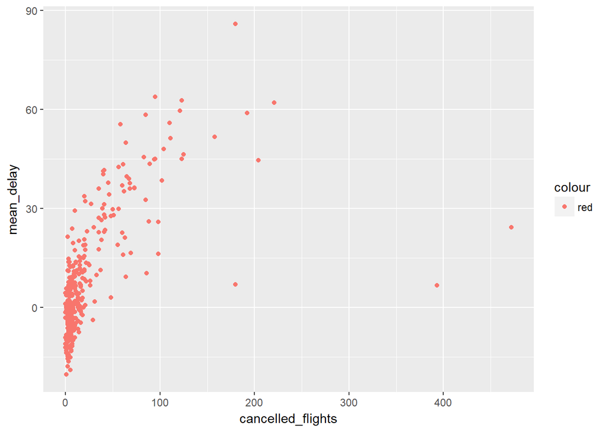

```r
ggplot(data = flights_pattern) +
  geom_point(mapping = aes(x = cancelled_flights, y=mean_delay, color = "red"))
```

Challenge: can you disentangle the effects of bad airports vs. bad carriers? Why/why not? (Hint: think about flights %>% group_by(carrier, dest) %>% summarise(n()))

It’s hard to tell. I think logistic regression would be able to produce faster and cleaner answer.

```r
flights %>%
  filter(!is.na(dep_delay)& dep_delay>0) %>%
  group_by(carrier) %>%
  summarize (avg_delay = (mean(dep_delay)),
             n()) %>%
  arrange(desc(avg_delay))
```

```
## # A tibble: 16 x 3
##    carrier avg_delay `n()`
##    <chr>       <dbl> <int>
##  1 OO           58.0     9
##  2 YV           53.0   233
##  3 EV           50.3 23139
##  4 9E           48.9  7063
##  5 F9           45.1   341
##  6 MQ           44.9  8031
##  7 HA           44.8    69
##  8 FL           40.8  1654
##  9 B6           39.8 21445
## 10 DL           37.4 15241
## 11 AA           37.2 10162
## 12 WN           34.9  6558
## 13 VX           34.5  2225
## 14 US           33.1  4775
## 15 AS           31.3   226
## 16 UA           29.9 27261
```

```r
flights %>%
  filter(!is.na(arr_delay) & arr_delay>0) %>%
  group_by(carrier) %>%
  summarize (avg_arr_delay = (mean(arr_delay)),
             n()) %>%
  arrange(desc(avg_arr_delay))
```

```
## # A tibble: 16 x 3
##    carrier avg_arr_delay `n()`
##    <chr>           <dbl> <int>
##  1 OO               60.6    10
##  2 YV               51.1   258
##  3 9E               49.3  6637
##  4 EV               48.3 24484
##  5 F9               47.6   392
##  6 VX               43.8  1746
##  7 FL               41.1  1895
##  8 WN               40.7  5304
##  9 B6               40.0 23609
## 10 AA               38.3 10706
## 11 MQ               37.9 11693
## 12 DL               37.7 16413
## 13 UA               36.7 22222
## 14 HA               35.0    97
## 15 AS               34.4   189
## 16 US               29.0  7349
```

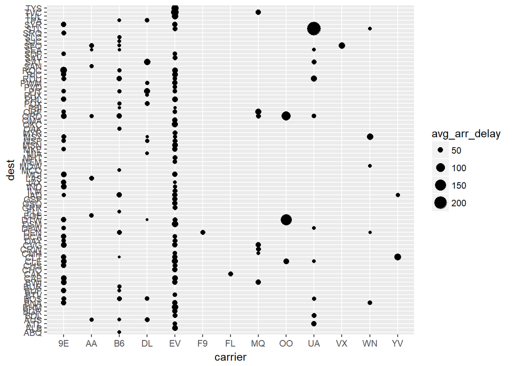

```r
flights %>%
  filter(!is.na(arr_delay) & arr_delay>0) %>%
  group_by(carrier, dest) %>%
  summarize (avg_arr_delay = (mean(arr_delay)),
              n=n()) %>%
  arrange(desc(n)) %>%
  filter(avg_arr_delay>40) %>%

  ggplot()+
  geom_point(mapping=aes(x=carrier, y=dest, size=avg_arr_delay))
```

6.What does the sort argument to count() do. When might you use it?

Sort orders the output in descending order of n, if set to TRUE. Can be used to sort output in cases where count is performed by another variable. e.g. count flights, by carrier

### Exercise 10.5

1.How can you tell if an object is a tibble? (Hint: try printing mtcars, which is a regular data frame).

mtcars is a data frame. first column does not have a header and variable type. Converting to tibble, deletes first column.

```r
print(mtcars)
```

```
##                      mpg cyl  disp  hp drat    wt  qsec vs am gear carb
## Mazda RX4           21.0   6 160.0 110 3.90 2.620 16.46  0  1    4    4
## Mazda RX4 Wag       21.0   6 160.0 110 3.90 2.875 17.02  0  1    4    4
## Datsun 710          22.8   4 108.0  93 3.85 2.320 18.61  1  1    4    1
## Hornet 4 Drive      21.4   6 258.0 110 3.08 3.215 19.44  1  0    3    1
## Hornet Sportabout   18.7   8 360.0 175 3.15 3.440 17.02  0  0    3    2
## Valiant             18.1   6 225.0 105 2.76 3.460 20.22  1  0    3    1
## Duster 360          14.3   8 360.0 245 3.21 3.570 15.84  0  0    3    4
## Merc 240D           24.4   4 146.7  62 3.69 3.190 20.00  1  0    4    2
## Merc 230            22.8   4 140.8  95 3.92 3.150 22.90  1  0    4    2
## Merc 280            19.2   6 167.6 123 3.92 3.440 18.30  1  0    4    4
## Merc 280C           17.8   6 167.6 123 3.92 3.440 18.90  1  0    4    4
## Merc 450SE          16.4   8 275.8 180 3.07 4.070 17.40  0  0    3    3
## Merc 450SL          17.3   8 275.8 180 3.07 3.730 17.60  0  0    3    3
## Merc 450SLC         15.2   8 275.8 180 3.07 3.780 18.00  0  0    3    3
## Cadillac Fleetwood  10.4   8 472.0 205 2.93 5.250 17.98  0  0    3    4
## Lincoln Continental 10.4   8 460.0 215 3.00 5.424 17.82  0  0    3    4
## Chrysler Imperial   14.7   8 440.0 230 3.23 5.345 17.42  0  0    3    4
## Fiat 128            32.4   4  78.7  66 4.08 2.200 19.47  1  1    4    1
## Honda Civic         30.4   4  75.7  52 4.93 1.615 18.52  1  1    4    2
## Toyota Corolla      33.9   4  71.1  65 4.22 1.835 19.90  1  1    4    1
## Toyota Corona       21.5   4 120.1  97 3.70 2.465 20.01  1  0    3    1
## Dodge Challenger    15.5   8 318.0 150 2.76 3.520 16.87  0  0    3    2
## AMC Javelin         15.2   8 304.0 150 3.15 3.435 17.30  0  0    3    2
## Camaro Z28          13.3   8 350.0 245 3.73 3.840 15.41  0  0    3    4
## Pontiac Firebird    19.2   8 400.0 175 3.08 3.845 17.05  0  0    3    2
## Fiat X1-9           27.3   4  79.0  66 4.08 1.935 18.90  1  1    4    1
## Porsche 914-2       26.0   4 120.3  91 4.43 2.140 16.70  0  1    5    2
## Lotus Europa        30.4   4  95.1 113 3.77 1.513 16.90  1  1    5    2
## Ford Pantera L      15.8   8 351.0 264 4.22 3.170 14.50  0  1    5    4
## Ferrari Dino        19.7   6 145.0 175 3.62 2.770 15.50  0  1    5    6
## Maserati Bora       15.0   8 301.0 335 3.54 3.570 14.60  0  1    5    8
## Volvo 142E          21.4   4 121.0 109 4.11 2.780 18.60  1  1    4    2
```

```r
mtcars1 <- as_tibble(mtcars) %>% print()
```

```
## # A tibble: 32 x 11
##      mpg   cyl  disp    hp  drat    wt  qsec    vs    am  gear  carb
##  * <dbl> <dbl> <dbl> <dbl> <dbl> <dbl> <dbl> <dbl> <dbl> <dbl> <dbl>
##  1  21.0  6.00   160 110    3.90  2.62  16.5  0     1.00  4.00  4.00
##  2  21.0  6.00   160 110    3.90  2.88  17.0  0     1.00  4.00  4.00
##  3  22.8  4.00   108  93.0  3.85  2.32  18.6  1.00  1.00  4.00  1.00
##  4  21.4  6.00   258 110    3.08  3.22  19.4  1.00  0     3.00  1.00
##  5  18.7  8.00   360 175    3.15  3.44  17.0  0     0     3.00  2.00
##  6  18.1  6.00   225 105    2.76  3.46  20.2  1.00  0     3.00  1.00
##  7  14.3  8.00   360 245    3.21  3.57  15.8  0     0     3.00  4.00
##  8  24.4  4.00   147  62.0  3.69  3.19  20.0  1.00  0     4.00  2.00
##  9  22.8  4.00   141  95.0  3.92  3.15  22.9  1.00  0     4.00  2.00
## 10  19.2  6.00   168 123    3.92  3.44  18.3  1.00  0     4.00  4.00
## # ... with 22 more rows
```

2.Compare and contrast the following operations on a data.frame and equivalent tibble. What is different? Why might the default data frame behaviours cause you frustration?

Default data frame can do partial match (df$x) whereas tibble cannot. Both work for second and third expressions. However, data frame returned a vector. With tibbles, [ always returns another tibble.

```r
df <- data.frame(abc = 1, xyz = "a")
df$x
```

```
## [1] a
## Levels: a
```

```r
df[, "xyz"]
```

```
## [1] a
## Levels: a
```

```r
df[, c("abc", "xyz")]
```

```
##   abc xyz
## 1   1   a
```

```r
df <- data.frame(abc = 1, xyz = "a")
df_tibble <- as_tibble(df)
df_tibble$x
```

[output not shown]

```r
df_tibble[, "xyz"]
```

```
## # A tibble: 1 x 1
##   xyz
##   <fct>
## 1 a
```

```r
df_tibble[, c("abc", "xyz")]
```

```
## # A tibble: 1 x 2
##     abc xyz
##   <dbl> <fct>
## 1  1.00 a
```

3. If you have the name of a variable stored in an object, e.g. var <- “mpg”, how can you extract the reference variable from a tibble? Yes, via [[var]]

```r
var <- "mpg"
df_tibble[[var]]
```

[output not shown]

6.What option controls how many additional column names are printed at the footer of a tibble

set print options with options(tibble.print_max = n, tibble.print_min = m) or via command print (n = number of rows, width = number of columns)

### Exerise 12.3.3

2.Why does this code fail? table4a %>% gather(1999, 2000, key = “year”, value = “cases”)

It fails because “1999” and “2000” are non-syntactic names - don’t start with a letter- they have to be surrounded by backticks

3. Why does spreading this tibble fail? How could you add a new column to fix the problem?

In this tibble age for Phillip Woods is listed twice. This might be a duplicate. We could add identifier column to distinguish between the two entries.This would produce 3 observations for Phillip. However, since we don’t know which age coincides to which height, this the best that could be done without consulting SME.

```r
people <- tribble(
  ~name,             ~key,    ~value,
  #-----------------|--------|------
  "Phillip Woods",   "age",       45,
  "Phillip Woods",   "height",   186,
  "Phillip Woods",   "age",       50,
  "Jessica Cordero", "age",       37,
  "Jessica Cordero", "height",   156
)

people <- people %>% unite(identifier, name, value, remove=FALSE)
print(people)
```

```
## # A tibble: 5 x 4
##   identifier          name            key    value
##   <chr>               <chr>           <chr>  <dbl>
## 1 Phillip Woods_45    Phillip Woods   age     45.0
## 2 Phillip Woods_186   Phillip Woods   height 186
## 3 Phillip Woods_50    Phillip Woods   age     50.0
## 4 Jessica Cordero_37  Jessica Cordero age     37.0
## 5 Jessica Cordero_156 Jessica Cordero height 156
```

```r
people_tidy <-
  spread(people, key, value)
print(people_tidy)
```

```
## # A tibble: 5 x 4
##   identifier          name              age height
##   <chr>               <chr>           <dbl>  <dbl>
## 1 Jessica Cordero_156 Jessica Cordero  NA      156
## 2 Jessica Cordero_37  Jessica Cordero  37.0     NA
## 3 Phillip Woods_186   Phillip Woods    NA      186
## 4 Phillip Woods_45    Phillip Woods    45.0     NA
## 5 Phillip Woods_50    Phillip Woods    50.0     NA
```

4.Tidy the simple tibble below. Do you need to spread or gather it? What are the variables?

this tibble needs to be gathered. Varibles: Pregnant, Sex

```r
preg <- tribble(
  ~pregnant, ~male, ~female,
  "yes",     NA,    10,
  "no",      20,    12
)

gather(preg, male, female, key="sex", value="value")
```

```
## # A tibble: 4 x 3
##   pregnant sex    value
##   <chr>    <chr>  <dbl>
## 1 yes      male    NA
## 2 no       male    20.0
## 3 yes      female  10.0
## 4 no       female  12.0
```

### Exercise 12.4.3: #1 and #2 only

1.What do the extra and fill arguments do in separate()? Experiment with the various options for the following two toy datasets.

Extra controls what happens when there are too many pieces - shows a warning on the Console, by default FIll controls controls what happens when there are not enough pieces - shows a warning on the Console, by default

```r
tibble(x = c("a,b,c", "d,e", "f,g,i")) %>%
  separate(x, c("one", "two", "three"), extra = "warn", fill = )
```

```
## Warning: Expected 3 pieces. Missing pieces filled with `NA` in 1 rows [2].
```

```
## # A tibble: 3 x 3
##   one   two   three
##   <chr> <chr> <chr>
## 1 a     b     c
## 2 d     e     <NA>
## 3 f     g     i
```

```r
tibble(x = c("a,b,c", "d,e,f,g", "h,i,j")) %>%
  separate(x, c("one", "two", "three"), extra = "warn")
```

[output not shown]

```
## # A tibble: 3 x 3
##   one   two   three
##   <chr> <chr> <chr>
## 1 a     b     c
## 2 d     e     f
## 3 h     i     j
```

2.Both unite() and separate() have a remove argument. What does it do? Why would you set it to FALSE?

Remove argument removes original data colums that are being united or separated (removes input column from output data frame). Set to FALSE if need to retain original data values.

### Additional Questions

Load baby_names.txt in R:

```r
file_path <- 'C:/Users/ipodvorna/Documents/compscix-415-2-assignments/compscix-415-2-assignments/baby_names.txt'
baby_names_data <- read_delim(file = file_path, delim = "|")
```

Take a glimpse of the output:

```r
glimpse(baby_names_data)
```

```
## Observations: 30,000
## Variables: 5
## $ year <int> 1880, 1880, 1880, 1880, 1880, 1880, 1880, 1880, 1880, 188...
## $ sex  <chr> "F", "F", "F", "F", "F", "F", "F", "F", "F", "F", "F", "F...
## $ name <chr> "Mary", "Anna", "Emma", "Elizabeth", "Minnie", "Margaret"...
## $ n    <int> 7065, 2604, 2003, 1939, 1746, 1578, 1472, 1414, 1320, 128...
## $ prop <dbl> 0.072384329, 0.026679234, 0.020521700, 0.019865989, 0.017...
```

```r
file_path_write <- 'C:/Users/ipodvorna/Documents/compscix-415-2-assignments/compscix-415-2-assignments/baby_names.csv'
write_csv(baby_names_data, path = file_path_write)
```

Export this file as an rds file and call it ‘baby_names.rds’:

```r
saveRDS(baby_names_data, file = 'C:/Users/ipodvorna/Documents/compscix-415-2-assignments/compscix-415-2-assignments/baby_names.rds')
```

Reload the baby_names.rds file and take another glimpse:

```r
baby_names_data_R <- readRDS('C:/Users/ipodvorna/Documents/compscix-415-2-assignments/compscix-415-2-assignments/baby_names.rds')

glimpse(baby_names_data_R)
```

```
## Observations: 30,000
## Variables: 5
## $ year <int> 1880, 1880, 1880, 1880, 1880, 1880, 1880, 1880, 1880, 188...
## $ sex  <chr> "F", "F", "F", "F", "F", "F", "F", "F", "F", "F", "F", "F...
## $ name <chr> "Mary", "Anna", "Emma", "Elizabeth", "Minnie", "Margaret"...
## $ n    <int> 7065, 2604, 2003, 1939, 1746, 1578, 1472, 1414, 1320, 128...
## $ prop <dbl> 0.072384329, 0.026679234, 0.020521700, 0.019865989, 0.017...
```